# Final_Project

Zhuojue Wang

2021/4/18

# 1. Introduction

In the recent times, we can collect many fitness data using device such as Jawbone Up, Nike FuelBand, and Fitbit. A group of enthusiasts collect barbell lifts data with 5 way to lifts the ball(sitting-down, standing-up, standing, walking, and sitting). We want to use the data provided from the team to build a model that able to predict the way of barbell lifts base on the data. I first load the testing and training data set and start to ddo some explotoary data analysis. By looking at the data, the participant’s name and the time which those data is collected is not relevant for our prediction algorithm. There are also many variable with some data but mostly NA. Which limit the use of preprocessing function to make estimate for those missing value. I decided remove both the irrelevant information and missing predictor from the data.

```r
#load Data Remove the non-numeric variable with we will not use the person and time of the exercise as predictor
pml_testing <- read_csv("C:/Users/PC/Downloads/pml-testing.csv")[-c(1:7)]
pml_training <- read_csv("C:/Users/PC/Downloads/pml-training.csv")[-c(1:7)]
#remove any colume with NA in there
pml_training <- pml_training[,colSums(is.na(pml_training)) == 0]
pml_testing <- pml_testing[,colSums(is.na(pml_testing)) == 0]

#pml_training
summary(pml_training)
```

```
##    roll_belt        pitch_belt          yaw_belt       total_accel_belt
##  Min.   :-28.90   Min.   :-55.8000   Min.   :-180.00   Min.   : 0.00
##  1st Qu.:  1.10   1st Qu.:  1.7600   1st Qu.: -88.30   1st Qu.: 3.00
##  Median :113.00   Median :  5.2800   Median : -13.00   Median :17.00
##  Mean   : 64.41   Mean   :  0.3053   Mean   : -11.21   Mean   :11.31
##  3rd Qu.:123.00   3rd Qu.: 14.9000   3rd Qu.:  12.90   3rd Qu.:18.00
##  Max.   :162.00   Max.   : 60.3000   Max.   : 179.00   Max.   :29.00
##   gyros_belt_x        gyros_belt_y       gyros_belt_z      accel_belt_x
##  Min.   :-1.040000   Min.   :-0.64000   Min.   :-1.4600   Min.   :-120.000
##  1st Qu.:-0.030000   1st Qu.: 0.00000   1st Qu.:-0.2000   1st Qu.: -21.000
##  Median : 0.030000   Median : 0.02000   Median :-0.1000   Median : -15.000
##  Mean   :-0.005592   Mean   : 0.03959   Mean   :-0.1305   Mean   :  -5.595
##  3rd Qu.: 0.110000   3rd Qu.: 0.11000   3rd Qu.:-0.0200   3rd Qu.:  -5.000
##  Max.   : 2.220000   Max.   : 0.64000   Max.   : 1.6200   Max.   :  85.000
##   accel_belt_y     accel_belt_z     magnet_belt_x   magnet_belt_y
##  Min.   :-69.00   Min.   :-275.00   Min.   :-52.0   Min.   :354.0
##  1st Qu.:  3.00   1st Qu.:-162.00   1st Qu.:  9.0   1st Qu.:581.0
##  Median : 35.00   Median :-152.00   Median : 35.0   Median :601.0
##  Mean   : 30.15   Mean   : -72.59   Mean   : 55.6   Mean   :593.7
##  3rd Qu.: 61.00   3rd Qu.:  27.00   3rd Qu.: 59.0   3rd Qu.:610.0
##  Max.   :164.00   Max.   : 105.00   Max.   :485.0   Max.   :673.0
##  magnet_belt_z       roll_arm         pitch_arm          yaw_arm
##  Min.   :-623.0   Min.   :-180.00   Min.   :-88.800   Min.   :-180.0000
##  1st Qu.:-375.0   1st Qu.: -31.77   1st Qu.:-25.900   1st Qu.: -43.1000
##  Median :-320.0   Median :   0.00   Median :  0.000   Median :   0.0000
##  Mean   :-345.5   Mean   :  17.83   Mean   : -4.612   Mean   :  -0.6188
##  3rd Qu.:-306.0   3rd Qu.:  77.30   3rd Qu.: 11.200   3rd Qu.:  45.8750
##  Max.   : 293.0   Max.   : 180.00   Max.   : 88.500   Max.   : 180.0000
##  total_accel_arm  gyros_arm_x        gyros_arm_y       gyros_arm_z
##  Min.   : 1.00   Min.   :-6.37000   Min.   :-3.4400   Min.   :-2.3300
##  1st Qu.:17.00   1st Qu.:-1.33000   1st Qu.:-0.8000   1st Qu.:-0.0700
##  Median :27.00   Median : 0.08000   Median :-0.2400   Median : 0.2300
##  Mean   :25.51   Mean   : 0.04277   Mean   :-0.2571   Mean   : 0.2695
##  3rd Qu.:33.00   3rd Qu.: 1.57000   3rd Qu.: 0.1400   3rd Qu.: 0.7200
##  Max.   :66.00   Max.   : 4.87000   Max.   : 2.8400   Max.   : 3.0200
##   accel_arm_x       accel_arm_y      accel_arm_z       magnet_arm_x
##  Min.   :-404.00   Min.   :-318.0   Min.   :-636.00   Min.   :-584.0
##  1st Qu.:-242.00   1st Qu.: -54.0   1st Qu.:-143.00   1st Qu.:-300.0
##  Median : -44.00   Median :  14.0   Median : -47.00   Median : 289.0
##  Mean   : -60.24   Mean   :  32.6   Mean   : -71.25   Mean   : 191.7
```

[output cut: 43 more lines]

```
##  Max.   :311.00000   Max.   :231.0000   Max.   : 477.00   Max.   : 923.0
##  accel_forearm_z   magnet_forearm_x  magnet_forearm_y magnet_forearm_z
##  Min.   :-446.00   Min.   :-1280.0   Min.   :-896.0   Min.   :-973.0
##  1st Qu.:-182.00   1st Qu.: -616.0   1st Qu.:   2.0   1st Qu.: 191.0
##  Median : -39.00   Median : -378.0   Median : 591.0   Median : 511.0
##  Mean   : -55.29   Mean   : -312.6   Mean   : 380.1   Mean   : 393.6
##  3rd Qu.:  26.00   3rd Qu.:  -73.0   3rd Qu.: 737.0   3rd Qu.: 653.0
##  Max.   : 291.00   Max.   :  672.0   Max.   :1480.0   Max.   :1090.0
##     classe
##  Length:19622
##  Class :character
##  Mode  :character
##
##
##
```

2. Data Partitioning For the reproducibility we set the seed for the random splitting process. I split the training data with a 60/40 split. I want to reduce the size of the training set for a faster computational process. We got 11776 sample in the training set and 7846 sample in the test set. I plot the frequency plot of classe in training and test set. I find the proportion is similar across group, that will make should we our test set has the similar data distribution with the training set

```r
#for reproducibility
set.seed(777)
#split the data 60% 40%
trainset <- createDataPartition(y=pml_training$classe, p=0.60, list=FALSE)

Train <- pml_training[trainset, ]
Test <- pml_training[-trainset, ]
dim(Train)
```

```
## [1] 11776    53
```

```r
dim(Test)
```

```
## [1] 7846   53
```

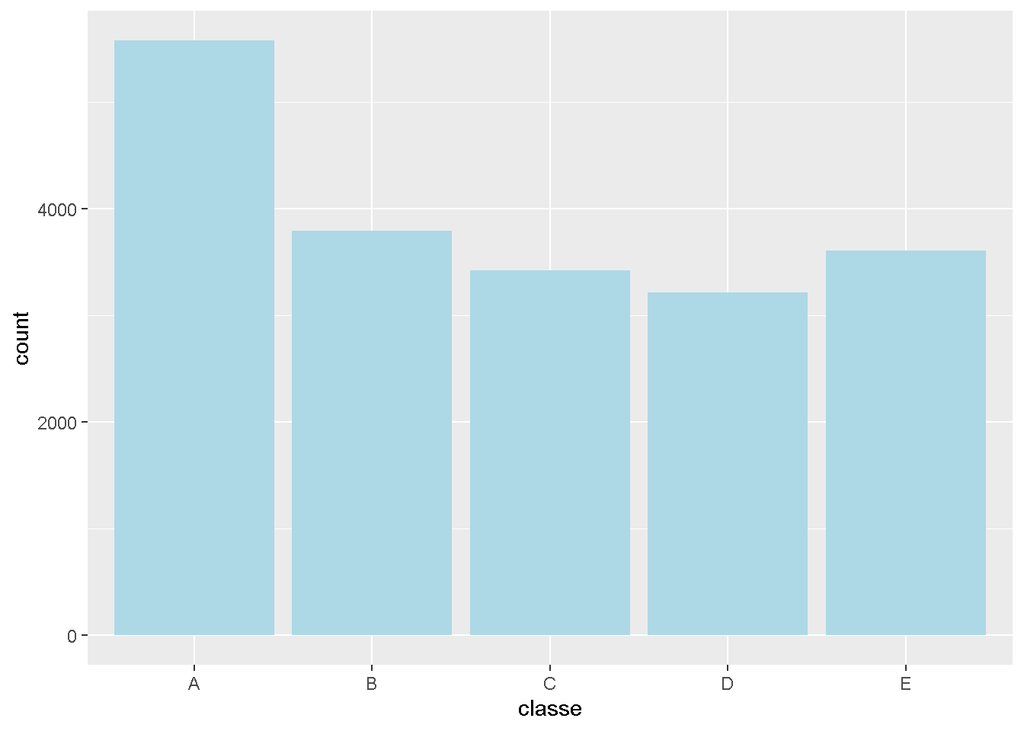

```r
ggplot(pml_training,aes(classe)) + geom_bar(fill = "Lightblue")
```

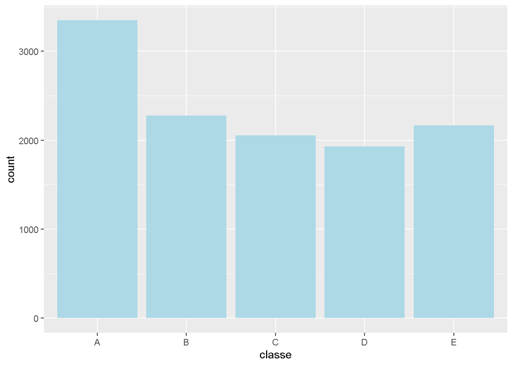

```r
ggplot(Train,aes(classe)) + geom_bar(fill = "Lightblue")
```

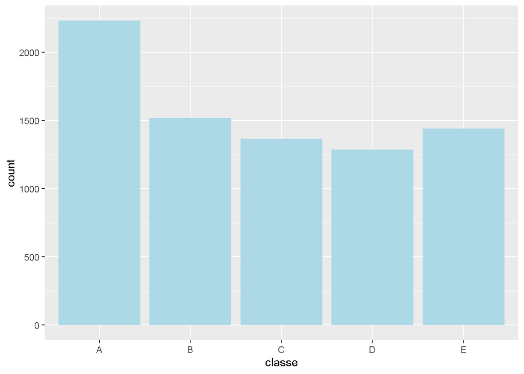

```r
ggplot(Test,aes(classe)) + geom_bar(fill = "Lightblue")
```

# Model Training

In order to make result reproducible I also set seed for the model training part. I choose 4 different algorithm, they are boosted tree, random forest, linear discriminant analysis and a stack model that combine the prediction of all three model and coming up with a stacked model. I also compute the accuracy bases on the testing set. The best model is random forest with accuracy of 0.9915881. The stack model has the same accuracy as the random forest. Since random forest is easier than the stack model, I choose random forest as the final model.

```r
set.seed(777)

mod_rf<-train(classe ~., data=Train, method="rf")
mod_gbm<-train(classe ~., data=Train, method="gbm")
mod_lda<-train(classe ~., data=Train, method="lda")



pred_rf<-predict(mod_rf,Test)
pred_gbm<-predict(mod_gbm,Test)
pred_lda<-predict(mod_lda,Test)
```

```r
#try stacked model
predDF<-data.frame(pred_rf, pred_gbm, pred_lda, classe=Test$classe)
combModFit<-train(classe ~., method="rf", data=predDF)
combPred<-predict(combModFit, predDF)
```

```r
confusionMatrix(factor(pred_rf),factor(Test$classe))$overall['Accuracy']
```

```
##  Accuracy
## 0.9915881
```

```r
confusionMatrix(factor(pred_gbm),factor(Test$classe))$overall['Accuracy']
```

```
##  Accuracy
## 0.9608718
```

```r
confusionMatrix(factor(pred_lda),factor(Test$classe))$overall['Accuracy']
```

```
##  Accuracy
## 0.7057099
```

```r
confusionMatrix(factor(combPred),factor(Test$classe))$overall['Accuracy']
```

```
##  Accuracy
## 0.9915881
```

# Test on test case

We use the random forest model as the final model to make 20 prediction on the test cases

```r
mod_rf
```

```
## Random Forest
##
## 11776 samples
##    52 predictor
##     5 classes: 'A', 'B', 'C', 'D', 'E'
##
## No pre-processing
## Resampling: Bootstrapped (25 reps)
## Summary of sample sizes: 11776, 11776, 11776, 11776, 11776, 11776, ...
## Resampling results across tuning parameters:
##
##   mtry  Accuracy   Kappa
##    2    0.9878400  0.9846132
##   27    0.9869625  0.9835033
##   52    0.9775736  0.9716240
##
## Accuracy was used to select the optimal model using the largest value.
## The final value used for the model was mtry = 2.
```

```r
final_pred_rf<-predict(mod_rf,pml_testing)
final_pred_rf
```

```
##  [1] B A B A A E D B A A B C B A E E A B B B
## Levels: A B C D E
```